# OpenCaseStudies - Right Heart Catheterization

Open Case Study Team

# Motivation

[Right heart catheterization (RHC)](https://www.hopkinsmedicine.org/healthlibrary/test_procedures/cardiovascular/right_heart_catheterization_135,40), also known as pulmonary artery catheterization, can be used to see how well or poorly a patient’s heart is pumping or to measure the pressure in a patient’s heart and lungs. Broadly, the procedure guides a pulmonary artery (PA) catheter (a small and hollow tube) through the pulmonary artery and into the right chambers of the heart. Here is a video to help describe in more detail how it works.

[video not shown]

[source: https://www.youtube.com/embed/xr-VkxUwceQ]

However, it is often the case that when a foreign object enters the human body, there is the risk of infection. RHC is no different. When the tube is put into the artery and a dye is injected into the heart, potential complications include the rupture of pulmonary artery or arrythmias of the heart where the heart may skip a beat.

To evaluate the benefit of RHCs, one approach would be to use a randomized controlled trial (RCT). However, because of the widespread belief that RHCs are beneficial and safe, it is difficult to obtain approval and support to conduct an RCTs. Without an RCT of RHCs, another approach to evaluate its effectiveness is to use an observational study.

The motivation of this case study is to investigate whether or not there is an impact on a patient’s overall survival (or mortality) due to treatment with a RHC, using an observational dataset. To answer this question, we will introduce tools used in survival analysis, including propensity scores and Cox Proportional Hazards models. We will eventually be able to make and interpret figures like this one, which illustrates the trajectory of survival probabilities over time for people who did or did not receive RHC.

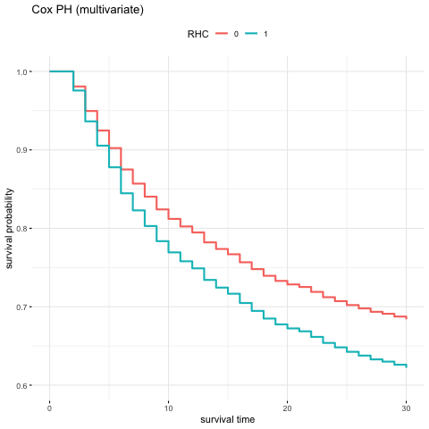

Our main predictor of interest is RHC, but we also want to adjust for other potential confounders in the dataset as this is an observational study. Here, we want to know whether RHC actually improves the patient’s overall survival within 30 days of being given a RHC, after adjusting for other baseline variables, including age, race, blood pressure, etc.

In addition to loading the set of R packages from the [`tidyverse`](https://www.tidyverse.org) that we will use for data manipulation, exploration and visualization, we also use the following R packages and describe their purpose for this this particular case study:

| R package | Purpose |
| --- | --- |
| `tableone` | Creates a table (‘Table 1’ below) to describe baseline characteristics of the sample |
| `kableExtra` | Helps with building complex tables and manipulating table styles; creates awesome HTML tables |
| `broom` | Takes the messy output of built-in functions in R such as `lm` or `t.test`, and turns it into tidy data frames |
| `ggpubr` | Provides some easy-to-use functions for creating and customizing `ggplot2`- based publication ready plots |
| `ggfortify` | Includes data visualization tools for statistical analysis results |
| `gridExtra` | Provides a number of user-level functions to work with “grid” graphics |
| `ggplot2` | Provides tools to create elegant data visualisations using the grammar of graphics |
| `survival` | Contains the core survival analysis routines, including definition of `Surv` objects, Kaplan-Meier and Cox models etc. |
| `survminer` | Contains functions for drawing Survival Curves using ‘ggplot2’ |
| `knitr` | Provides a general-purpose tool for dynamic report generation in R |
| `MatchIt` | Includes functions for nonparametric preprocessing for parametric causal inference |

In order to run this code please ensure you have these packages installed.

```r
library(tableone)
library(kableExtra)
library(tidyverse)
library(broom)
library(ggpubr)
library(ggfortify)
library(gridExtra)
library(ggplot2)
library(survival)
library(survminer)
library(knitr)
library(MatchIt)
```

The learning objectives for this case study include:

- some basic data wrangling and visualizations (using the `tidyverse` packages)
- a causal inference method: propensity score matching (using the `MatchIt` package)
- multivariate logistic regression (using the `stats` package)
- survival analysis (using the `survival` package)

# What is the data?

The data are available to download as a `.csv` file at this [link](http://biostat.mc.vanderbilt.edu/wiki/pub/Main/DataSets/rhc.csv). The dataset includes a set of patients who were hospitialized and either did or did not receive an RHC (also called a Swan-Ganz catheter) on day 1 of hospitalization. This treatment variable is called `swang1` in the dataset. The description of all variables can be found in the [codebook](http://biostat.mc.vanderbilt.edu/wiki/pub/Main/DataSets/rhc.html).

# Data Import

As the data are avaiable online, we will import them from the web directly with the `read_csv()` function from the [`readr` package](https://cran.r-project.org/web/packages/readr/readr.pdf) as part of the `tidyverse`. This dataset was originally used in in the paper [1], and has been made publicly available.

```r
file <- "http://biostat.mc.vanderbilt.edu/wiki/pub/Main/DataSets/rhc.csv"
rhc <- read_csv(file)
```

Let’s take a quick look at the first five rows and five columns of the dataset:

```r
rhc[1:5, 1:5]
```

```
## # A tibble: 5 x 5
##      X1 cat1              cat2          ca    sadmdte
##   <dbl> <chr>             <chr>         <chr>   <dbl>
## 1     1 COPD              <NA>          Yes     11142
## 2     2 MOSF w/Sepsis     <NA>          No      11799
## 3     3 MOSF w/Malignancy MOSF w/Sepsis Yes     12083
## 4     4 ARF               <NA>          No      11146
## 5     5 MOSF w/Sepsis     <NA>          No      12035
```

To get a sense of how many observations or columns we have, we can use the `dim()` function:

```r
dim(rhc)
```

```
## [1] 5735   63
```

We will talk more about what the column names mean in the next section.

# Data Wrangling

## Variable selection

As we saw, there are in total 63 variables in the dataset. In this case study, we will select a subset of variables. If you are interested, you can change the list below to include other variables as a future exercise.

```r
rhc_df <-
  rhc %>%
    select(age = age,
           sex = sex,
           race = race,
           education = edu,
           income = income,
           med_ins = ninsclas,
           disease = cat1,
           cancer = ca,
           weight = wtkilo1,
           temp = temp1,
           bp = meanbp1,
           resp = resp1,
           hrt = hrt1,
           pf = pafi1,
           ph = ph1,
           death = dth30,
           time = t3d30,
           RHC = swang1)
```

According to the [codebook](http://biostat.mc.vanderbilt.edu/wiki/pub/Main/DataSets/rhc.html), a summary of the variables we are interested in is given below.

| variable names | meaning |
| --- | --- |
| `age` | Age |
| `sex` | Sex |
| `race` | Race |
| `education` | Years of education |
| `income` | Income |
| `med_ins` | Medical insurance |
| `disease` | Primary disease category |
| `cancer` | Cancer |
| `weight` | Weight |
| `temp` | Temperature |
| `bp` | Mean blood pressure |
| `resp` | Respiratory rate |
| `rth` | Heart rate |
| `pf` | PaO2/FIO2 ratio, ratio of arterial oxygen partial pressure to fractional inspired oxygen |
| `ph` | PH |
| `time` | Survival time of each patient in 30 days |
| `death` | Indicates whether the patient survived or dead in 30 days |
| `RHC` | Right heart catheterization |

# Exploratory data analysis

Our main interest is to investigate the influence of RHC on survival. but first let’s use exploratory data analysis (EDA) to explore the relationship between RHC and the other variables in our dataset.

First, we can stratify the samples in our data set into two groups according to the `RHC` column of the `rhc_df` dataset : the samples who either did or did not receive the RHC procedure. Then, we can summarize the potential confounders within each group to determine if there are differences in these potential confounders between the two groups. These demographic summaries can help us understand the one to one relation between right heart catheterization and other variables.

We will use the function `CreateTableOne()` in the [`tableone` package](https://www.rdocumentation.org/packages/tableone/versions/0.10.0) to summarize both continuous and categorical variables with respect to the `RHC` column in our dataset. Then, we can use statistical tests (specifically Chi-square and *t*-tests) to investigate the relationship between `RHC` and either continuous or categorical variables.

```r
tblprint <-
  CreateTableOne(data = rhc_df, strata = 'RHC') %>%
  print()

tblprint[c(3, 4, 9, 14, 21, 31, 42, 44),4] <- 'Chi-sq'
tblprint[c(2, 8, 35, 36, 37, 38, 39, 40, 41, 43),4] <- 't-test'
```

The `CreateTableOne()` function creates an object summarizing all baseline variables, optionally stratifying by one or more variables and performing statistical tests. The p-values from the statistical test comparing the two groups is given in the `p` column. To make this object easy to manipulate, e.g., to be able to change values or use the `kable()` function to display the table, we use the function `print()` to change its type to a dataframe.

```r
kable(tblprint , "html",
      caption = "Stritified by Right Heart Catheterization", booktabs = T) %>%
  kable_styling('responsive') %>%
  add_indent(c(5:7, 10:13,15:20,22:30,32:34))
```

Stritified by Right Heart Catheterization

|  | No RHC | RHC | p | test |
| --- | --- | --- | --- | --- |
| n | 3551 | 2184 |  |  |
| age (mean (SD)) | 61.76 (17.29) | 60.75 (15.63) | 0.026 | t-test |
| sex = Male (%) | 1914 (53.9) | 1278 ( 58.5) | 0.001 | Chi-sq |
| race (%) |  |  | 0.425 | Chi-sq |
| black | 585 (16.5) | 335 ( 15.3) |  |  |
| other | 213 ( 6.0) | 142 ( 6.5) |  |  |
| white | 2753 (77.5) | 1707 ( 78.2) |  |  |
| education (mean (SD)) | 11.57 (3.13) | 11.86 (3.16) | 0.001 | t-test |
| income (%) |  |  | <0.001 | Chi-sq |
| > $50k | 257 ( 7.2) | 194 ( 8.9) |  |  |
| $11-$25k | 713 (20.1) | 452 ( 20.7) |  |  |
| $25-$50k | 500 (14.1) | 393 ( 18.0) |  |  |
| Under $11k | 2081 (58.6) | 1145 ( 52.4) |  |  |
| med_ins (%) |  |  | <0.001 | Chi-sq |
| Medicaid | 454 (12.8) | 193 ( 8.8) |  |  |
| Medicare | 947 (26.7) | 511 ( 23.4) |  |  |
| Medicare & Medicaid | 251 ( 7.1) | 123 ( 5.6) |  |  |
| No insurance | 186 ( 5.2) | 136 ( 6.2) |  |  |
| Private | 967 (27.2) | 731 ( 33.5) |  |  |
| Private & Medicare | 746 (21.0) | 490 ( 22.4) |  |  |
| disease (%) |  |  | <0.001 | Chi-sq |
| ARF | 1581 (44.5) | 909 ( 41.6) |  |  |
| CHF | 247 ( 7.0) | 209 ( 9.6) |  |  |
| Cirrhosis | 175 ( 4.9) | 49 ( 2.2) |  |  |
| Colon Cancer | 6 ( 0.2) | 1 ( 0.0) |  |  |
| Coma | 341 ( 9.6) | 95 ( 4.3) |  |  |
| COPD | 399 (11.2) | 58 ( 2.7) |  |  |
| Lung Cancer | 34 ( 1.0) | 5 ( 0.2) |  |  |
| MOSF w/Malignancy | 241 ( 6.8) | 158 ( 7.2) |  |  |
| MOSF w/Sepsis | 527 (14.8) | 700 ( 32.1) |  |  |
| cancer (%) |  |  | 0.001 | Chi-sq |
| Metastatic | 261 ( 7.4) | 123 ( 5.6) |  |  |
| No | 2652 (74.7) | 1727 ( 79.1) |  |  |
| Yes | 638 (18.0) | 334 ( 15.3) |  |  |
| weight (mean (SD)) | 65.04 (29.50) | 72.36 (27.73) | <0.001 | t-test |
| temp (mean (SD)) | 37.63 (1.74) | 37.59 (1.83) | 0.429 | t-test |
| bp (mean (SD)) | 84.87 (38.87) | 68.20 (34.24) | <0.001 | t-test |
| resp (mean (SD)) | 28.98 (13.95) | 26.65 (14.17) | <0.001 | t-test |
| hrt (mean (SD)) | 112.87 (40.94) | 118.93 (41.47) | <0.001 | t-test |
| pf (mean (SD)) | 240.63 (116.66) | 192.43 (105.54) | <0.001 | t-test |
| ph (mean (SD)) | 7.39 (0.11) | 7.38 (0.11) | <0.001 | t-test |
| death = Yes (%) | 1088 (30.6) | 830 ( 38.0) | <0.001 | Chi-sq |
| time (mean (SD)) | 24.19 (9.76) | 22.67 (10.44) | <0.001 | t-test |
| RHC = RHC (%) | 0 ( 0.0) | 2184 (100.0) | <0.001 | Chi-sq |

The `kable()` function is a very simple table generator and enables you to create awesomes tables by playing with its arguments. Here, we use the `kable_styling()` function to modify the style of HTML output, and use the `add_indent()` function to add indentations to the row headers. All of this work is aimed to construct a nice table.

Knowing information about how these characteristics differ between patients that were or were not managed with `RHC` is important because we want to identify the impact of `RHC` on survival, independent of other differences in the two populations of patients (e.g. whether they have cancer or not). We will learn in a little bit more about how to overcome these differences between the two groups, and isolate the effect of RHC on mortality, below.

## Data visualization

Next, let’s use data visualization to explore the relationships between RHC and the other variables in our dataset. Here, we will use the `ggplot2` package from the `tidyverse`.

First, let’s explore the `sex`, `race` and `med_ins` variables with respect to the `RHC` column. We will show different barplots using the `geom_bar()` function in `ggplot2`. We also use the `ggarrange` function from the [`ggpubr` package](https://cran.r-project.org/web/packages/ggpubr/index.html) to arrange the subfigures into one plot.

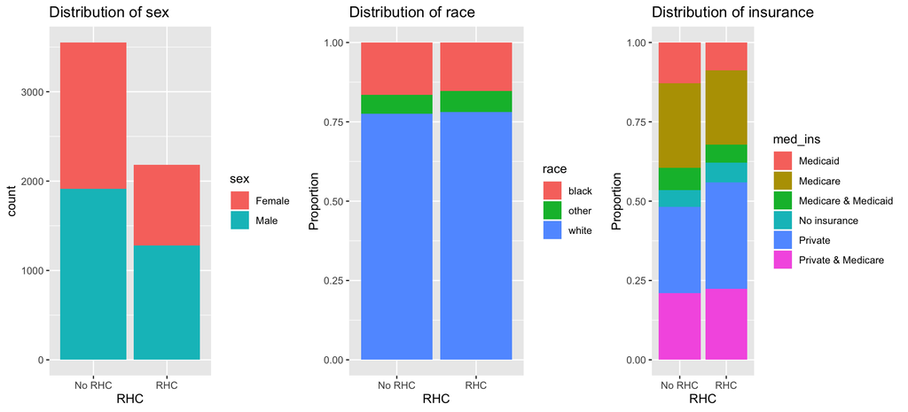

```r
p1 <- rhc_df %>%
        ggplot(aes(x = RHC, fill = sex)) +
          geom_bar() +
           ggtitle('Distribution of sex')
p2 <- rhc_df %>%
        ggplot(aes(x = RHC, fill = race)) +
          geom_bar(position = "fill") +
           ggtitle('Distribution of race') +
          ylab('Proportion')

p3 <- rhc_df %>%
        ggplot(aes(x = RHC, fill = med_ins)) +
          geom_bar(position = "fill") +
           ggtitle('Distribution of insurance') +
          ylab('Proportion')

ggarrange(p1, p2, p3, ncol=3, nrow=1)
```

The difference between the left plot and the other two plots, is the middle and right plots use the `position='fill'` option in the `geom_bar()` function. In this case, it shows the proportion rather than count making the y-axis cover the entire range between 0 and 1.

These plots further match our understanding of the characteristics of patients: patients managed with RHC were more likely to be white males (teal and blue in left two plots) and to have private insurance (blue in right plot). Here we just provide three examples, but we encourage you to try more variables that you are interested in!

Besides these three categorical variables, we also pick three continuous variables and visualize them.

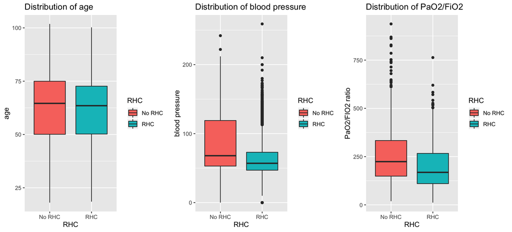

```r
p4 <- rhc_df %>%
        ggplot(aes(x = RHC, y = age, fill = RHC)) +
          geom_boxplot() +
           ggtitle('Distribution of age')
p5 <- rhc_df %>%
        ggplot(aes(x = RHC, y = bp, fill = RHC)) +
          geom_boxplot() +
           ggtitle('Distribution of blood pressure') +
            ylab('blood pressure')
p6 <- rhc_df %>%
        ggplot(aes(x = RHC, y = pf, fill = RHC)) +
          geom_boxplot() +
            ggtitle('Distribution of PaO2/FiO2') +
              ylab('PaO2/FIO2 ratio')


ggarrange(p4, p5,p6, ncol=3, nrow=1)
```

The `age` difference between the RHC and No RHC groups seem to be negligible, while blood pressure (`bp`) and PaO2/FIO2 ratio (`pf`) have larger differences. We see that patients who receive RHC tend to have lower blood pressure (`bp`) than patients who do not. Similarly, patients who receive RHC tend to have lower PaO2/FIO2 ratio (`pf`), which indicates that blood pressure and PaO2/FIO2 ratio might be related to whether or not a patient receives the RHC treatment.

# Data analysis

Because we want to investigate the impact of receiving the `RHC` treatment on a patient’s 30-day survival, we will use a branch of statistics called [survival analysis](https://en.wikipedia.org/wiki/Survival_analysis). These methods can be used to analyze the expected duration of time until one or more events happen, such as death in biological organisms or failure in mechanical systems.

## Survival analysis

### Right censoring

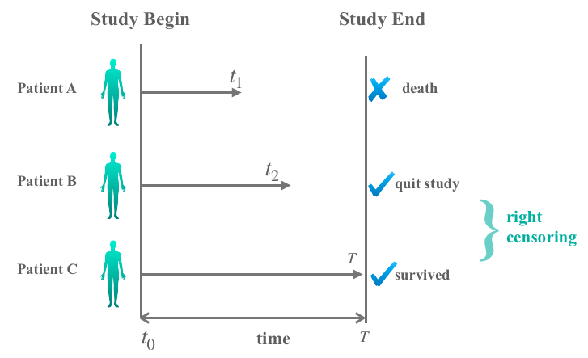

Suppose there are three patients, A, B and C who enroll in the study at time $t_0$, and the length of this study is $T$. Assume patient A died at time $t_1$. In this case, we know his exact survival time and this patient is not censored. Next, assume patient B quit the study at time $t_2$, before the end of the study ($T$). And patient C was alive at the end of the study ($T$). In these cases, we treat patient B and patient C as *right censored* because we know the patients were alive at time $t_2$ and $T$ respectively, but do not know when death happened afterwards. Right censoring plays an important role here in determining survival time: the real survival time will always be equal to or greater than the observed survival time for right censored data.

### Kaplan-Meier

In consideration of right censoring, the [Kaplan-Meier estimator](https://www.ncbi.nlm.nih.gov/pmc/articles/PMC3059453/) can be a good choice to estimate the survival rate. It is a non-parametric method used to estimate the probability of survival. In general, the survival probability is calculated as one minus the probablity of death. At each time interval, the probability of death equals the number of patients who died ($d_i$) divided by the number of patients at risk of dying ($n_i$). Here, the Kaplan-Meier estimator excludes the following people from the denominator: those who have died, those who withdrew from the study, those who are lost to follow-up, or those who are alive without event occurrence at last follow-up (right-censored) - based on status at the time in question. Otherwise it is likely that the probability of death will be underestimated.

The estimated survival function is written as:

$$\widehat{S(t)}\ =\prod_{i:\ t_i\leq t}(1-\frac{d_i}{n_i})$$

where $t_i$ is the time when at least one event happened. You can think of the method as a series of declining horizontal steps which, with a large enough sample size, approaches the true survival function for that population.

The `Surv()` function in the [`survival` package](https://www.rdocumentation.org/packages/survival/versions/2.11-4) uses a specific class from the `survival` package to create a specialized object. It takes as input both the time to the event (`time`) and whether or not the event has happened by the end of the study (`death`) and then creates an object that describes when right censoring has occurred.

Let’s look at the `Surv()` function help file

```r
?Surv
```

We see we need variables for the `time` and `event` arguments to create a `Surv` object. In our data frame we can use the `time` variable for the `time` argument. For the `event` argument, we can use the `death` variable, which is the response varable in our survival analysis.

**Note**: In the help file, for the `event` argument, it states that

> “The status indicator, normally 0=alive, 1=dead. Other choices are TRUE/FALSE (TRUE = death) or 1/2 (2=death).”

Let’s look at the data type of the `death` column in the `rhc_df` data frame.

```r
str(rhc_df$death)
```

```
##  chr [1:5735] "No" "No" "No" "No" "Yes" "No" "No" "No" "No" "No" "No" ...
```

We see it is a vector of character strings. So to create a `Surv` object, we need to convert the datatype of the column to a numeric. To do this we will use the `mutate()` function in the [`dplyr` package](https://www.rdocumentation.org/packages/dplyr/versions/0.7.8) to transform the factor to a numeric variable. While we are here, we will also change the data type of `RHC` to be encoded as 0 for “No RHC” and 1 for “RHC”

```r
rhc_df <- rhc_df %>%
  mutate(death = if_else(death == "No", 0, 1),
         RHC = if_else(RHC == "No RHC", 0, 1))
```

Let’s check on what the datatypes are now.

```r
str(rhc_df$death)
```

```
##  num [1:5735] 0 0 0 0 1 0 0 0 0 0 ...
```

```r
str(rhc_df$RHC)
```

```
##  num [1:5735] 0 1 1 0 1 0 0 0 0 1 ...
```

Now we are ready to run the `Surv()` function.

```r
sur_obj <- Surv(rhc_df$time, rhc_df$death)
sur_obj[1:10]
```

```
##  [1] 30+ 30+ 30+ 30+  2  30+ 30+ 30+ 30+ 30+
```

Do you see `+` behind some of the survival times? This is an example of what we discussed before: right censored data points. `30+` indicates this patient survived until the end of the study while the `2` means this patient died at the second day after study began.

Also, the `sur_obj` object can be interpreted by the `survfit()` function from the `survival` package (see below) which is used to compute an estimate of a survival curve for censored data. In addition to the `sur_obj` object that we created, the `survfit()` function also requires as input the response variable of interest in a simple case of right-censored data. Here that is the `RHC` variable.

```r
fit <- survfit(sur_obj ~ RHC, data = rhc_df)
fit
```

```
## Call: survfit(formula = sur_obj ~ RHC, data = rhc_df)
##
##          n events median 0.95LCL 0.95UCL
## RHC=0 3551   1088     NA      NA      NA
## RHC=1 2184    830     NA      NA      NA
```

The reason why we get ‘NA’ here is: the median survival time is the time at which the survival rate equals 0.5. In our case, since minimum survival rate is over 0.6, it never gets as low as 0.5, and thus the output shows ‘NA’.

The total number of the patients managed by RHC is 2184, and 830 of them died within 30 days (or a proportion of 0.38). The total number of the patients not having RHC is 3551, and 1088 of them died in 30 days (or a proportion of 0.31).

To show a visual display of the survival curve, the function [`ggsurvplot()`](https://www.rdocumentation.org/packages/survminer/versions/0.4.4/topics/ggsurvplot) from the package [`survminer`](https://cran.r-project.org/web/packages/survminer/index.html) can be used to create a Kaplan-Meier curve for `survfit` objects. `ggurvplot()` returns an object of class `ggsurvplot` which is a list containing the survival plot, the data used to create the plot, etc. We can also use this to show the survival rate stratified by whether or not a patient was managed with `RHC`.

**Note**: Here we are not adjusting for any other covariates, and we are only considering the `RHC` variable. In the sections below, we will discuss how to adjust for other covariates.

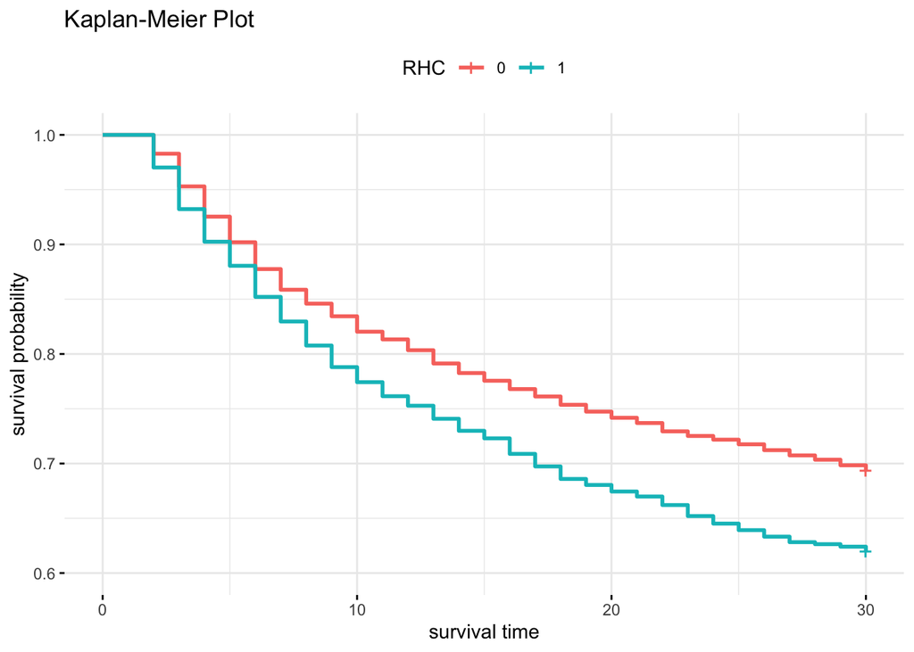

```r
p_km <- ggsurvplot(fit, ylim = c(0.6, 1),
      legend.title = "RHC",
      legend.labs = c("0", "1"),
       ylab = 'survival probability',
       xlab = 'survival time',
       title = 'Kaplan-Meier Plot',
       ggtheme = theme_minimal())

p_km
```

The x-axis is the survival time, and the y-axis is the survival probability. The small vertical tick-marks indicate individual patients whose survival times have been right-censored. It looks like a step function since the probability changes each day (the event data are recorded daily). When no truncation or censoring occurs, the Kaplan-Meier curve is the complement of the empirical distribution function.

Some further description of the plot: at the beginning, all the patients are alive. The survival probability at the end of 30 days of a patient having a right catheterization is 0.62 compared to 0.69 for patients not having the right catheterization.

We see from the Kaplan-Meier plot that patients with RHC treatment have a lower survival rate. But, think back to the ‘Data visualization’ section. We also saw a difference in the distribution for covariates such as blood pressure. This suggests that patients who are or are not managed by RHC might be different from one another due to other covariates as well. Therefore, the difference in observed survival rates might be driven by differences in the other covariates. Our goal is to determine whether RHC has an impact on survival, but we want to make a fair comparison between the patients managed with and without RHC. Therefore, we are curious if there is still a difference in survival after adjusting for potential confounders. We will introduce propensity scores and propensity score matching in the next few sections as a way to do this adjustment.

## Propensity score matching

As we mentioned above, it is a popular belief that it is beneficial for patients to be managed by RHC [1]. Therefore, a RCT is not possible. However, one of the main benefits of an RCT is that randomization helps us to isolate the effect we are interested in measuring, by making sure the two comparison groups are otherwise similar on all other relevant variables. In an observational data set, this is rarely the case, especially when variables are used to assign treatment that may also have an impact on patient survival. The Connors et al. paper explains this phenomenon like this:

> In observational studies, the treatment selection has a connection with patient characteristics but also has a link with the outcomes. For example, patients with lower blood pressure are more likely to get RHC, and they are also more likely to die. The effect of such treatment selection bias has been called “confounding by indication”.

### Propensity score: conceptual framework

The propensity score is defined as the probability a patient receives a treatment, taking into account the complete information about this patient. The information may include variables that affect the chance that the patient receives the treatment, such as `age`, `gender`, `blood pressure` etc. To use propensity scores, we need a way to estimate this probability for each patient, and then figure out how to use these propensity scores to isolate the effect we are interested in measuring, i.e., the effect of RHC on patient survival.

It turns out that we can estimate the propensity score using a tool we may have used in other contexts: logistic regression. To set up the logistic regression model, the potentially informative variables are treated as explanatory variables in the model, while the response variable is a binary variable indicating whether or not this patient received treatment. In our case, this is the `RHC` variable. The sections below will go into more detail about the reasoning behind using propensity scores, how we calculate them, and how we use them in our survival analysis.

### Propensity score matching: conceptual framework

To adjust for treatment selection bias, the variables that independently affect the decision to use or withhold the treatment must be identified, measured and somehow adjusted for. Here we will accomplish this adjustment with what’s called [propensity score matching (PSM)](https://en.wikipedia.org/wiki/Propensity_score_matching).

In a statistical analysis with observational data, PSM is a technique that attempts to estimate the effect of a treatment, policy, or other intervention by modeling covariates that predict receiving the treatment, and then matching patients who had similar probabilities of receiving treatment, but who had different treatment assignments. These pairs of patients are similar to each other in terms of their prior chance of receiving treatment, so when we compare their outcomes, we are controlling for those things that influenced the treatment decision. PSM attempts to reduce the bias due to the confounding variables by ensuring that outcomes among units that received the treatment are compared fairly to outcomes that did not receive the treatment. When we say “fairly”, we mean that the outcomes have similar probabilities of receiving the treatment.

In general, the procedures of PSM include:

- Run logistic regression:
  - Dependent variable: Y = 1, if with RHC; Y = 0, otherwise.
  - Choose appropriate confounders and apply multivariate logistic regression.
  - Obtain propensity score, which is the predicted probability (p) of receiving treatment. A higher score indicates a higher probability of receiving the treatment.
- One-to-one matching on propensity score:
  - Randomly select one patient with RHC.
  - Match this patient who has the closest propensity score in all patients without RHC. The difference should be less than a certain threshold (to be discussed later)
  - Continue this matching until all possible pairs are identified.

Let’s use a plot to explain how the matching works.

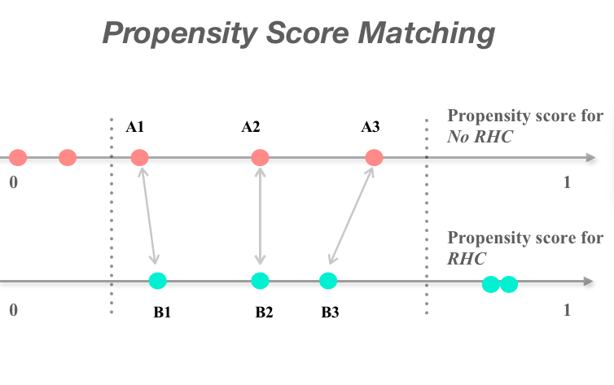

Each dot represents a patient in the observational study, grouped and colored according to whether they received (bottom line, teal) or did not receive (top line, pink) RHC. The position of the point on the line reflects the propensity score from 0 (on the left) to 1 (on the right). A larger propensity score reflects a higher probability of receiving the treatment and vice versa for a lower score. In the cartoon, there are 5 patients who receive the RHC treatment (teal) and 5 patients without RHC treatment (pink). Using the covariates in a logistic regression model, we estimate the propensity score. Then, we match patients based on propensity score across the two groups. The closer their propensity score is,the more likely they will be matched as a pair.

Here, there are 3 pairs in the middle: A1 and B1, A2 and B2, A3 and B3, as these are the closest matching pairs. However, there are 2 samples on the left in the No RHC group and 2 samples on the right in the RHC group (separated by dashed line) that do not matches. This is because there are no samples whose propensity scores are close to theirs. In this case, they fail to be matched and will be removed from downstream analyses. After the matching is complete, we have 3 pairs of patients that are matched successfully (or 3 samples with RHC treatment and 3 samples without RHC treatment).

### Estimating propensity scores: the details

As we mentioned above, the propensity score is calculated using logistic regression in which the treatment assignment is the dependent variable. Logistic regression measures the relationship between a set of predictor variables and a binary (0 or 1) outcome. Based on the estimated logistic regression model, we can predict the probability that any indvidual, with a certain set of values of the predictor variables, has an outcome value of 1. The `glm()` function in the [`stats` package](https://stat.ethz.ch/R-manual/R-devel/library/stats/html/00Index.html) is widely used to estimate generalized linear models, of which logistic regression is a special case. The argument `family =` provides a convenient way to specify the details of the models used. Here, since the outcome is binary and we would like to fit a logistic regression model, we set `family = binomial(link = "logit")`.

We exclude `time` and `death` here because these two variables have no relationship with treatment assignment (`RHC`) and only relate to the survival analysis that we will perform later on. Since these two variables were measured after treatment, they were not involved in the determination of whether a patient received RHC.

```r
psm_glm <- glm(RHC ~ . - time - death,
               family = binomial(link = "logit"),
               data = rhc_df)
```

Using this model, we can calculate the propensity score for each patient. It is simply the patient’s predicted probability of receiving a RHC, given the estimated coefficients from the logit model. To do this, we will use the `predict()` function and create a data frame that has the propensity score as well as the patient’s actual treatment status.

```r
p_rhc = predict(psm_glm, type = "response")
glm_df <- data.frame(p_rhc = p_rhc,
                     p_norhc =  1 - p_rhc,
                     RHC =  psm_glm$model$RHC)
```

Inside the data frame, the `p_rhc` is the predicted probability of being assigned to RHC, while `p_norhc` is the predicted probability of being assigned to no RHC.

After estimating the propensity score, we can plot the propensity scores by treatment status using histograms.

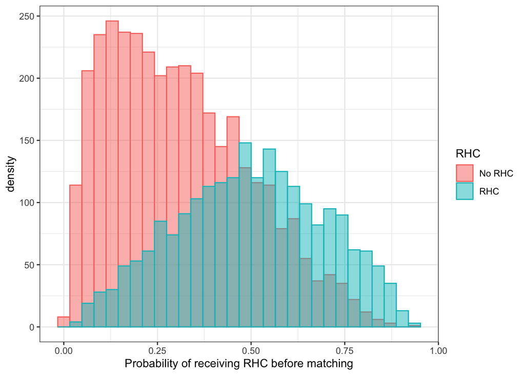

```r
glm_df %>%
  mutate(RHC = ifelse(RHC == 1, "RHC", "No RHC")) %>%
  ggplot(aes(x = p_rhc,fill = RHC, color = RHC)) +
  geom_histogram(alpha=0.5, position = 'identity')+
  xlab("Probability of receiving RHC before matching") +
  ylab("density") + theme_bw()
```

Note that you can change the `position` adjustment to use for overlapping points on the layer (default value is `position ='stack'`). In contrast, the `position = 'identity'` argument will place each object exactly where it falls in the context of the graph. Finally, since we have overlapping bars we can make the bars slightly transparent by setting `alpha` to a small value.

We can clearly see the distribution of propensity scores is not balanced across the two groups. This is not surprising since we know that the decision to give a patient a RHC was made based on some of the variables included in our model; the patients who received a RHC were more likely to receive one than the patients who did not. In order to make our RHC and non-RHC groups more comparable to one another, we will move to the next step: one-to-one matching.

### One-to-one matching on propensity score

Based on the example above, you might think that it would be a lot of work to find the best set of matching samples from the treatment and control groups in our data set. However, other people have written some useful code to make this process much easier.

The `matchit()` function is the main command of the package [`MatchIt`](https://cran.r-project.org/web/packages/MatchIt/MatchIt.pdf), which uses parametric models for causal inference to select well-matched subsets of the original treated and control groups.

The arguments of the `matchit()` function are given below:

- `formula`: Specifies the logistic regression formula you would like to use. Here, we just use the same logistic regression model, `psm_glm`, that we created in last section.
- `data`: Data frame (or database table name) containing the variables for analysis in the formula arguments.
- `method =`: Specifies the matching methods. Options include:
  - `exact`: Matches each treated unit with a control unit that has exactly the same values on each covariate. It is useless when there are too many variables.
  - `subclass`: Breaks the data set into subclasses so the distributions of the covariates are similar in each subclass.
  - `nearest`: Matches a pair that is closest in terms of a distance measure (This is the default method).
  - `optimal`: Minimize the average absolute distance across all matched pairs.
- `caliper`: For the nearest neighbor matching, this has a further restriction that the absolute difference in the propensity scores of matched subjects must be below some prespecified threshold (the `caliper` distance). [3] suggested using a caliper size of one-fifth of a standard deviation of the sample estimated propensity scores.
- `ratio`: Indicates the ratio of treatment cases to control cases to match. Default is one-to-one matching. You can increase the number of control cases matched to each treatment case by increasing this number; usually this number is between 1 and 5.

If we dig into [3], we will find that to specify the value of `caliper` (or the threshold), the standard deviation of the log odds of the estimated propensity scores is necessary. We calculated these propensity scores in the previous section. We see that the `p_rhc` will be useful now!

First let’s calculate our threshold that we will use in `caliper`.

```r
epsilon <- 0.2*sd(log(p_rhc/(1-p_rhc)))
```

Then, we can run the `matchit()` function!

```r
set.seed(1234)
psm_mod <- matchit(RHC ~ age + sex + race + education +
                     income + med_ins + disease + cancer +
                     weight + temp + bp + resp + hrt + pf +
                     ph, data = rhc_df, method = "nearest",
                   caliper  = epsilon, ratio = 1)

rhc_psm_df <- match.data(psm_mod)
colnames(rhc_psm_df)
```

```
##  [1] "age"       "sex"       "race"      "education" "income"
##  [6] "med_ins"   "disease"   "cancer"    "weight"    "temp"
## [11] "bp"        "resp"      "hrt"       "pf"        "ph"
## [16] "death"     "time"      "RHC"       "distance"  "weights"
```

Using the `match.data()` function, we can get the final dataset with matched patients (`rhc_psm_df`). Note that the final dataset is smaller than the original: it contains 3724 observations, meaning that 1862 pairs of treated and control observations were matched. It also contains a variable called `distance`, which is the propensity score.

Let’s check out what the distribution of propensity scores looks like in our matched dataset:

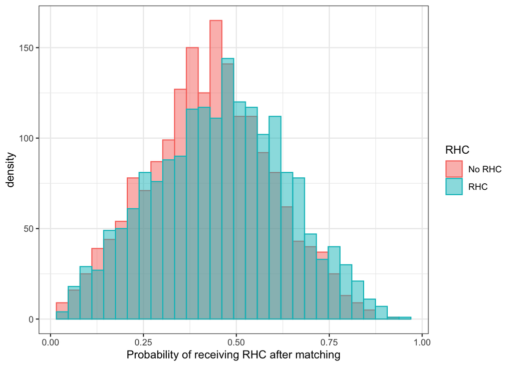

```r
rhc_psm_df %>%
  mutate(RHC = ifelse(RHC == 1, "RHC", "No RHC")) %>%
  ggplot(aes(x = distance,fill = RHC, color = RHC)) +
  geom_histogram(alpha = 0.5, position = 'identity') +
  xlab("Probability of receiving RHC after matching") +
  ylab('density') + theme_bw()
```

Now the distributions of propensity scores in the two groups are much more balanced! In addition to using `ggplot2`, there is another way to present this result using the [`plot()` function](https://www.rdocumentation.org/packages/MatchIt/versions/1.0-2/topics/plot.matchit) inside the `MatchIt` package.

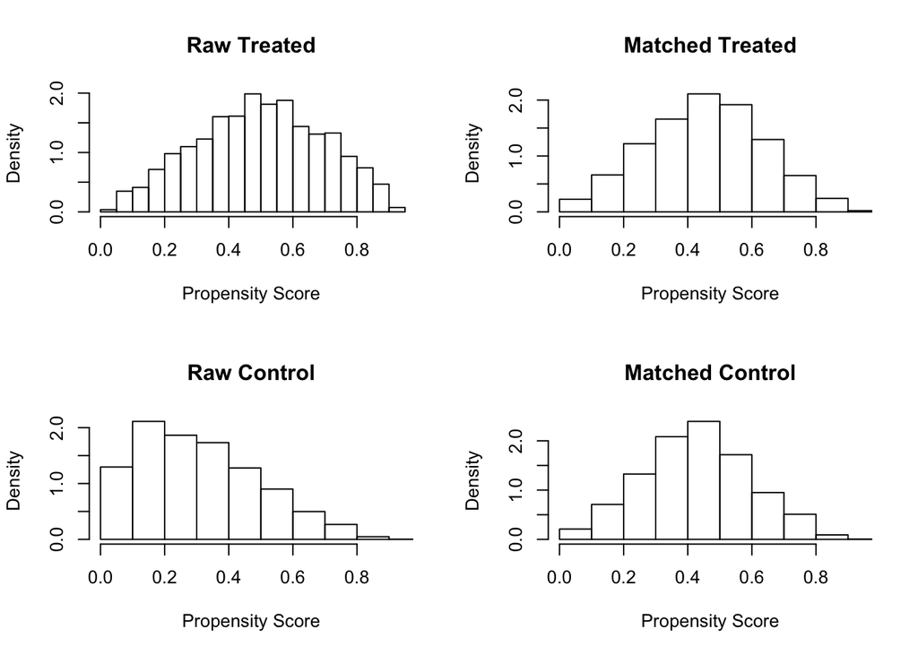

```r
plot(psm_mod,type = "hist" )
```

Just putting the `psm_mod` object in `plot()` produces a nice plot, showing the distributions of propensity scores before and after matching. The histograms before matching are on the left, and the histograms after matching are on the right.

## Cox proportional hazards model

Given our new balanced data set, let’s continue to investigate the effect of RHC on the probability of survival for the patients who were or were not treated with RHC.

In our Kaplan-Meier plot, we created the `sur_obj` object with the time that passes (`time`), and the event that occurs (`death`) in order to plot the survival curve. This non-parametric method is a simple comparision which can be used to get a first-pass understanding based on a single covariate (e.g. `RHC`). More often than not, we want to estimate survival probablities taking into account additional characteristics that may influence the outcome, such as `blood pressure`, or `age`. In our case, we are interested in the effect of `RHC`, but we also know there are additional covariates that might effect the outcome. So, we would like to adjust for these additional covariates.

This is where we will introduce the [Cox proportional hazards model](https://en.wikipedia.org/wiki/Proportional_hazards_model) (Cox PH model), which is essentially a regression model used to investigate the association between the survival time of patients and one or more predictor variables. While the Kaplan-Meier curve is an example of a *univariate* analysis (only describing the survival with respect to one covariate), the Cox PH model can be a *multivariate* model that simultaneously assesses the effect of multiple covariates on survival time.

We will first give an overview of the concepts behind a Cox PH model, then provide some background theory that you can take a look at if you are interested.

### Overview of the Cox PH model

The Cox PH model is expressed using the hazard function $h(t)$ at time $t$. The intepretation of the hazard function is the risk of dying at time $t$, so you can think it as a time-specific chance of dying. For the $i^{th}$ observation and a given set of covariates $\mathbf{X}_i = \{ X_{i1}, \ldots X_{ip} \}$, the Cox PH model has the form

$$h(t | \mathbf{X}_i)= h_0(t) e^{\beta_1 X_{i1} + \ldots \beta_p X_{ip}}
= h_0(t) e^{\beta \mathbf{X}_{i}}$$

where the coefficients $\beta = \{\beta_1, \ldots, \beta_p \}$ are the effect sizes of the covariates $\mathbf{X}_i$. The Cox PH model allows us to investigate the relationship between the covariates $\mathbf{X}_i$ and the chance of death, considering that the chance of death may vary over time accoring to $h_0(t)$, which is called the “baseline hazard function at time $t$”.

**Note**: If you take the natural log of the hazard function, you get a linear model with a baseline hazard function (intercept) that varies over time.

Here, $h_0(t)$ is the baseline hazard at time $t$. This is the hazard if all the $\mathbf{X}_i$ are 0. A **key assumption** of the Cox PH model is that the hazard curves for groups of observations should be proportional and cannot cross.

To be specific, consider the $i^{th}$ and $j^{th}$ observations and suppose we have only one covariate $X_1$, with observed values $x$ and $x^{'}$ for the $i^{th}$ and $j^{th}$ observations. The ratio of their hazard functions is

$$\frac{h_i(t|X_{1} = x)}{h_j(t|X_{1} = x^{'})}=\frac{h_0(t) e^{\beta x}}{h_0(t) e^{\beta x^{'}}}=e^{\beta (x-x^{'})}$$

which is independent of time! Another way of phrasing this is that the hazard for any observation is a constant multiple of the hazard for any other observation.

How do we interpret the coefficients from the Cox PH model? The values $e^{\beta}$ are called hazard ratios (HRs). If $\beta > 0$ (or $e^{\beta}$ > 1), this implies that as $X_{1}$ increases, the hazard increases and thus the survival probability decreases. In constrast, if the HR is less than 1, then this is a reduction in the hazard (or an increase in survival).

If you take log of the above formula, you will get

$$log(h_i(t|X_{1} = x)) - log (h_j(t|X_{1} = x^{'})) = \beta (x-x^{'})$$

Now, we can see that the slopes $\beta$ are interpretable as differences in the log(hazard) for a difference in $X_{1}$ at a given time, $t$.

Another transformation of the hazard function, $h(t)$ that can be useful is the “complementary log-log” model (or $log(-log(1-h(t)))$). This transformation can be useful when the probability of an event is very small or very large.

### Background theory

To get a sense of what the hazard function is in a more detailed mathematical way, let’s first consider the survival function. If $T$ is a continous random variable representing the time of death, with probability distribution $f(t)$ and cumulative distribution $F(t)$ that represents the survival time, we can describe the cumulative distribution function as

$$F(t) = Pr(T < t)$$

The complement of the cumulative distribution is survival function $S(t)$

$$S(t) \equiv Pr(T \geq t) = \int_{t}^{\infty} f(t) dt$$

where $f(t)$ is the probability density function at time $t$.

Now, as mentioned above, the hazard function is risk of dying at time $t$. Another way of phrasing this is given the patient was alive at time $t$, what’s the conditional probability of dying in the next time interval of length $\Delta t$, or that the event, death, will occurr in the interval $[t, t+ \Delta t)$.

$$h(t) =\displaystyle{\lim_{\Delta t \to 0}}
\frac{ P(t \leq T <t+\Delta t|T \ge t)}{\Delta t}
= \frac{ P(t \leq T <t+\Delta t)}{P(T \ge t) \Delta t}
= \frac{ f(t) \Delta t}{S(t) \Delta t}$$

which can be written as the joint probability of the event occuring in the interval $[t, t+ \Delta t)$ and $T \ge t$ (which is the same as the event occuring in the interval $[t, t+ \Delta t)$), divided by the probability of $T \ge t$. The numerator is just $f(t) \Delta t$ for small $\Delta t$ and denominator is just $S(t)$.

If we divide by $\Delta t$ and take the limit as $\Delta t \to 0$, then the hazard function is just

$$h(t) = \frac{f(t)}{S(t)}$$

### Model application

Now, we can fit a Cox PH model using the `coxph()` function, from the `survival` package. Similiar to when we estimated a Kaplan-Meier curve, we first create a survival object using the `Surv()` function (e.g. `Surv(time, death)`).

In the next section, we will first fit a few univariate Cox PH models to illustrate the model behavior and interpretation. We will then fit a multivariate Cox PH model using all the covariates in our dataset (`rhc_psm_df`). We note that both of these models are using the data after matching based on propensity scores. However, to isolate the effect of interest, we still want to include the covariates in the model to estimate a conditional treatment effect.

#### Univariate Cox PH model

To fit a univariate Cox PH model, we include only one variable in the Cox PH model formula. Here we select the `RHC`, `age` and `weight` variables as examples, and show the results.

A univariate Cox PH model for `RHC` is given by

```r
fit_uni1 <- coxph(Surv(time, death) ~ RHC,
              data = rhc_psm_df)
```

We can also use the `tidy()` function in the [`broom`](https://cran.r-project.org/web/packages/broom/index.html) package to create a `tidy` representation of the model output as a `data.frame` object.

```r
res <- tidy(fit_uni1, conf.int = TRUE,
                conf.level = 0.95)
res
```

```
## # A tibble: 1 x 7
##   term  estimate std.error statistic   p.value conf.low conf.high
##   <chr>    <dbl>     <dbl>     <dbl>     <dbl>    <dbl>     <dbl>
## 1 RHC      0.241    0.0559      4.31 0.0000160    0.132     0.351
```

What does this model output tell us? The coefficient here (`estimate`) is the $\beta$ coefficient from the model formulation described above, where we have only one covariate, RHC. More specifically, we have fit the model:
$$h(t | X)= h_0(t) e^{\beta_1 X}$$

where $X=1$ if the patient received RHC and $X=0$ if not and $h_0(t)$ is the baseline hazard at time $t$. Again referring to the results from above, we have:

$$\frac{h(t| RHC)}{h(t|no RHC)}=\frac{h_0(t) e^{\beta * 1}}{h_0(t) e^{\beta * 0}}=e^{\beta}$$

Our model output tells us that we on average have multiplicative change in hazard of $e^{\beta}$=exp(0.241)=1.273, comparing a person with RHC ($X=1$) to one without ($X=0$). This exponentiated coefficient, whose value is 1.273, is the hazard ratio comparing someone with RHC to someone without RHC. If the exponentiated coefficient is larger than 1, the model estimates that the variable will increase the hazard of the event occuring (or decrease the survival probability). The model output also contains a p-value and 95% confidence interval for the coefficient; in this case, we can see that $\beta$ is statistically significantly different from 0 since the p-value is < 0.05 and the confidence interval does not contain the null value of 0.

Note, we can also ask to report the coefficients (`estimate`) and confidence intervals on an exponential scale with the `exponentiate = TRUE` argument.

```r
res_exp <- tidy(fit_uni1, exponentiate = TRUE,
            conf.int = TRUE, conf.level = 0.95)
res_exp
```

```
## # A tibble: 1 x 7
##   term  estimate std.error statistic   p.value conf.low conf.high
##   <chr>    <dbl>     <dbl>     <dbl>     <dbl>    <dbl>     <dbl>
## 1 RHC       1.27    0.0559      4.31 0.0000160     1.14      1.42
```

Note that now, we want to check whether the confidence interval contains 1, which is the null value for the hazard ratio. We can see that the significance results match those from the non-exponentiated model output, which makes sense.

Next, a univariate Cox PH model for `age` is given by

```r
fit_uni2 <- coxph(Surv(time, death) ~ age,
              data = rhc_psm_df)

res <- tidy(fit_uni2, exponentiate=TRUE,
            conf.int = TRUE, conf.level = 0.95)
res
```

```
## # A tibble: 1 x 7
##   term  estimate std.error statistic  p.value conf.low conf.high
##   <chr>    <dbl>     <dbl>     <dbl>    <dbl>    <dbl>     <dbl>
## 1 age       1.01   0.00178      6.63 3.37e-11     1.01      1.02
```

We can see that for each additional year in age, the hazard is estimated to change by a multiplicative factor of 1.012 and that this estimate is again statistically significantly different from the null value of 1.

Finally, a univariate Cox PH model for `weight` is given by

```r
fit_uni3 <- coxph(Surv(time, death) ~ weight,
              data = rhc_psm_df)

res <- tidy(fit_uni3, exponentiate=TRUE,
            conf.int = TRUE, conf.level = 0.95)
res
```

```
## # A tibble: 1 x 7
##   term   estimate std.error statistic p.value conf.low conf.high
##   <chr>     <dbl>     <dbl>     <dbl>   <dbl>    <dbl>     <dbl>
## 1 weight    0.998   0.00100     -1.53   0.127    0.997      1.00
```

Looking at the results, we see that `RHC` and `age` are associated with survival, while `weight` does not have a statistically significant effect.

#### Multivariate Cox PH model

Next, we will fit a Cox PH model using the `coxph()` function and include all the covariates in our dataset (`rhc_psm_df`), after propensity score estimation.

First, we recall the column names in our dataset:

```r
colnames(rhc_psm_df)
```

```
##  [1] "age"       "sex"       "race"      "education" "income"
##  [6] "med_ins"   "disease"   "cancer"    "weight"    "temp"
## [11] "bp"        "resp"      "hrt"       "pf"        "ph"
## [16] "death"     "time"      "RHC"       "distance"  "weights"
```

To incorproate all the variables in the model, we can use the `~ .` R model formula syntax, but we need to use the negative sign (`-`) to exclude some variables. We see the propensity score (`distance`) and weights (`weights`) that were calcuated by `matchit()` are included in our data frame, but are not needed in model fitting. We also do not want to include the covariates `time` or `death` as these covariates are used in the `sur_obj` object to note right censored observations.

```r
fit_all <- coxph(Surv(time, death) ~ . - time - death -
              distance - weights,
              data = rhc_psm_df)

res <- tidy(fit_all, conf.int = TRUE,
                conf.level = 0.95)
head(res)
```

```
## # A tibble: 6 x 7
##   term           estimate std.error statistic    p.value conf.low conf.high
##   <chr>             <dbl>     <dbl>     <dbl>      <dbl>    <dbl>     <dbl>
## 1 age              0.0113   0.00236      4.79 0.00000170  0.00666    0.0159
## 2 sexMale          0.135    0.0583       2.31 0.0207      0.0206     0.249
## 3 raceother        0.449    0.135        3.33 0.000857    0.185      0.714
## 4 racewhite        0.211    0.0862       2.44 0.0145      0.0418     0.380
## 5 education        0.0169   0.0102       1.65 0.0986     -0.00315    0.0369
## 6 income$11-$25k   0.200    0.125        1.60 0.110      -0.0449     0.444
```

Again, we can report the results on the exponential scale, so that the esimates are interpretable as hazard ratios:

```r
res_exp <- tidy(fit_all, exponentiate = TRUE,
            conf.int = TRUE, conf.level = 0.95)
head(res_exp)
```

```
## # A tibble: 6 x 7
##   term           estimate std.error statistic    p.value conf.low conf.high
##   <chr>             <dbl>     <dbl>     <dbl>      <dbl>    <dbl>     <dbl>
## 1 age                1.01   0.00236      4.79 0.00000170    1.01       1.02
## 2 sexMale            1.14   0.0583       2.31 0.0207        1.02       1.28
## 3 raceother          1.57   0.135        3.33 0.000857      1.20       2.04
## 4 racewhite          1.23   0.0862       2.44 0.0145        1.04       1.46
## 5 education          1.02   0.0102       1.65 0.0986        0.997      1.04
## 6 income$11-$25k     1.22   0.125        1.60 0.110         0.956      1.56
```

```r
tail(res_exp)
```

```
## # A tibble: 6 x 7
##   term  estimate std.error statistic     p.value conf.low conf.high
##   <chr>    <dbl>     <dbl>     <dbl>       <dbl>    <dbl>     <dbl>
## 1 bp       0.996  0.000871     -5.10 0.000000345    0.994     0.997
## 2 resp     1.00   0.00211       1.20 0.230          0.998     1.01
## 3 hrt      1.00   0.000716      2.21 0.0272         1.00      1.00
## 4 pf       0.999  0.000297     -2.72 0.00656        0.999     1.000
## 5 ph       0.544  0.252        -2.42 0.0156         0.332     0.891
## 6 RHC      1.28   0.0562        4.34 0.0000140      1.14      1.43
```

Looking at these results, we can see that RHC has a very similar estimated effect here and in the univariate Cox PH model we fit above. In both cases, the effect of RHC is to increase the chance of death for the patient, with a hazards ratio of 1.28, whose confidence interval is 1.14 to 1.43.

### Check the fundamental assumption

Now that we have fit our Cox PH model, let’s check the assumptions of the Cox PH model in our data. If you recall, the **fundamental assumption** of the Cox PH model is that the model assumes the hazard is constant with time. For instance, in our case we want to evaluate the relationship between patients being managed with the RHC treatment and the hazard of death, controlling for possible confounding variables which might be related to death. But what if some variables’ values change over time?

#### Complementary log-log plot

One way to check the fundamental assumption is to use a data visualization. A plot that shows a non-random pattern of hazard against time may indicate a violation of the assumption.

The first plot we will consider is the “complementary log-log” model, which displays ($ln(-ln(1-h(t)))$ or $ln(-ln(S(t)))$ vs. $ln(t)$. For a given variable (e.g. `RHC`), here is a cartoon of what it looks like if the assumption is not violated:

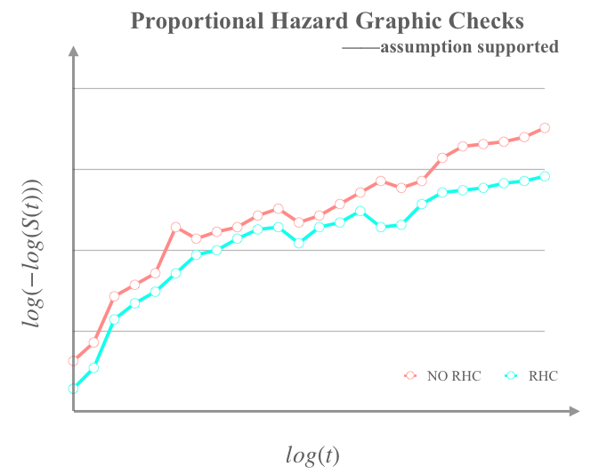

And here is a cartoon of what it might look like if the assumption is violated:

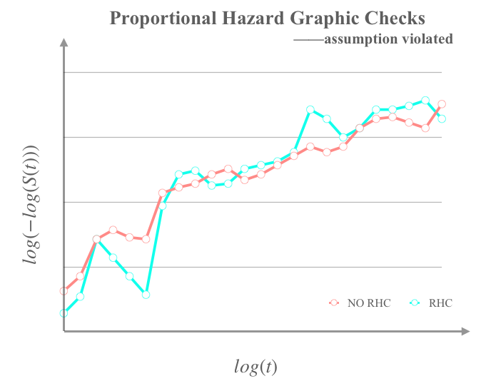

Here we see that the survival curves cross, clearly indicating a violation of the proportional hazards assumption, i.e., the ratio of the baseline hazard values is not constant over time, but is smaller or bigger as the lines get closer together or farther apart.

Now let’s look at this visualization using our data. We still use `ggsurvplot()` to plot it. The `fun` option is an arbitrary function defining a transformation of the survival curve, and we use `log(-log(x))` to get the complementary log-log plot:

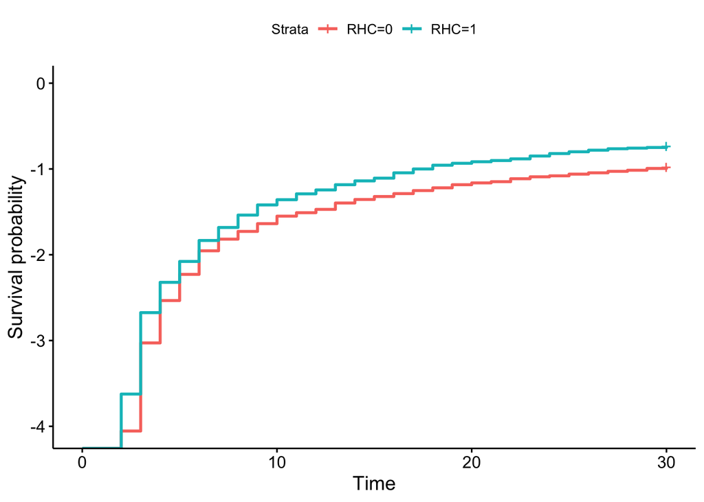

```r
sur_obj2 <- Surv(rhc_psm_df$time, rhc_psm_df$death)

ggsurvplot(survfit(sur_obj2 ~ RHC, data = rhc_psm_df),
           fun = function(x){log(-log(x))})
```

Looking at this plot, it appears that our dataset doesn’t violate the assumption.

#### Statistical assessments

Another approach to assess the model assumptions is to use a formal statistical test. Here we will use the `cox.zph()` function in the `survival` package. It tests for proportionality of all the variables specified in the model by creating interaction terms with time (on the log scale). Then, the function will test for independence of each variable. If the interaction terms are non-significant, the conclusion is that the effect of that covariate does not vary with time. The function also performs a global test for all the interactions tested together in the model. If the p-value is less than 0.05, this suggests a violation of the PH assumption. [4]

For instance, if our model is $ln(h(t|X_1))= \beta_0 + \beta_1 X_1$ (where $\beta_0 = \ln(h_0(t))$), to test whether $X_1$ is time-varying, the `cox.zph()` function creates an interaction term $X_1*ln(t)$ in the model. Now the model is

$$ln~h(t|X_1)= \beta_0 + \beta_1~X_1 + \beta_2(X_1*ln~t)$$

Using a null hypothesis of $H_0: \beta_2=0$, we can assess whether or not there is a relationship with time according to whether we reject or fail to reject this null hypothesis. Note, a p-value less than a specified Type 1 error (e.g. $\alpha$ = 0.05) suggests there is evidence that the effect of the variable ($X_1$) is time-varying.

To illustrate the test, we use our data set as an example, and we use the `fit_all` Cox PH model from above. The `transform` argument describes how the survival times should be transformed before the test is performed. For example, we use `transform = log` to get $X*ln~t$ in our model.

```r
check.ph <- cox.zph(fit_all, transform = 'log')
check.ph
```

```
##                                  rho    chisq       p
## age                         0.020394 5.57e-01 0.45528
## sexMale                    -0.011927 1.87e-01 0.66563
## raceother                   0.004630 2.82e-02 0.86666
## racewhite                  -0.038565 1.97e+00 0.16055
## education                  -0.047122 2.85e+00 0.09116
## income$11-$25k             -0.012105 1.96e-01 0.65806
## income$25-$50k             -0.023586 7.41e-01 0.38923
## incomeUnder $11k           -0.032955 1.50e+00 0.22100
## med_insMedicare             0.020851 5.57e-01 0.45529
## med_insMedicare & Medicaid  0.013182 2.26e-01 0.63433
## med_insNo insurance         0.022318 6.58e-01 0.41740
## med_insPrivate              0.014366 2.68e-01 0.60444
## med_insPrivate & Medicare   0.017398 3.87e-01 0.53387
## diseaseCHF                 -0.000648 5.48e-04 0.98133
## diseaseCirrhosis            0.003753 1.87e-02 0.89125
## diseaseColon Cancer        -0.046479 2.42e-07 0.99961
## diseaseComa                -0.047757 2.92e+00 0.08760
## diseaseCOPD                 0.054133 3.80e+00 0.05117
## diseaseLung Cancer         -0.003908 1.99e-02 0.88770
## diseaseMOSF w/Malignancy    0.005568 4.65e-02 0.82931
## diseaseMOSF w/Sepsis        0.002318 6.78e-03 0.93436
## cancerNo                   -0.011498 2.02e-01 0.65350
## cancerYes                   0.011610 1.98e-01 0.65666
## weight                      0.023056 6.33e-01 0.42621
## temp                       -0.038182 1.97e+00 0.16072
## bp                          0.024814 8.61e-01 0.35333
## resp                       -0.037206 1.81e+00 0.17910
## hrt                        -0.003388 1.50e-02 0.90248
## pf                         -0.005411 4.06e-02 0.84029
## ph                          0.067900 6.87e+00 0.00876
## RHC                         0.020838 5.66e-01 0.45196
## GLOBAL                            NA 3.23e+01 0.40224
```

The first column (`rho`) gives the Pearson product-moment correlation between the scaled [Schoenfeld residuals](https://www.mbaskool.com/business-concepts/statistics/8766-schoenfeld-residuals-test.html) and `log(time)` for each covariate, which is the difference between the covariate for that subject and the weighted average of covariates in the risk set. The last row contains the global test for all the interactions tested at once.

We notice the p-value for `ph` is less than 0.05, suggesting that there may be a violation of the Cox PH assumptions for this variable. If you recall, this variable represents the PH level from the patient.

Let’s explore this a bit more with a graphical assessment of the Schoenfeld residuals. Here we pick out 6 variables (`age`, `sex`, `education`, `diseaseComa` and `diseaseCOPD`, as well as `ph`) and graphically assess whether or not there is a relationship between the variable and time. We will use the function `ggcoxzph` in the package `survminer`, which will generate plots of residuals for individual predictors against time, where a non-zero slope is evidence against the Cox PH assumption.

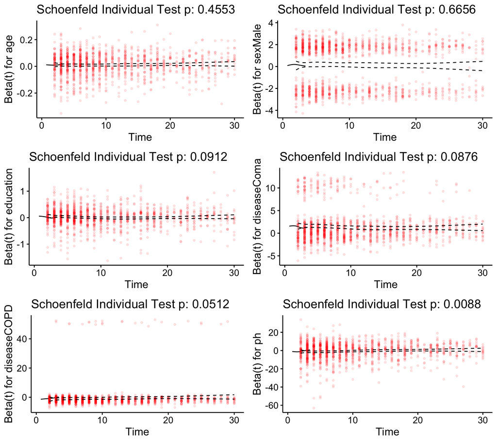

```r
#get graphical diagnostic for `age`, `sex`, `education`, `diseaseComa`, `diseaseCOPD` and `ph`
plist <- ggcoxzph(check.ph, point.alpha = 0.1)[c(1,2,5,17,18,30)]
#plot them in one chunk
grid.arrange(grobs = lapply(plist, ggplotGrob), ncol =2)
```

The `grid.arrange()` function in the package `gridExtra` can be used to arrange several plots in an array. The `ggcoxzph` function, rather than generating plots, returns an object which is a list of ggplot objects, , or more specifically, gtables. These `gtables` are matrix-like layouts placed in cells that can be directly used as an input in the `grid` system of graphics and related packages. So to convert them to ggplot objects, we use the `ggplotGrob()` function in the package `ggplot2` to generate ggplot2 grobs that are compatible with function `grid.arrange()`.

In the figures above, the solid line is a smoothing spline fit to the plot, with the dashed lines representing a 95% confidence interval around this smoothed line. As we said, an apparent departure from a horizontal line indicates violation for the proportional hazards assumption. All of these 6 variables have a zero slope, suggesting the assumption is not violated. For more information on graphical diagnostics, we refer the reader to [2]:

> “We prefer graphical checks to formal goodness-of-fit test because we believe that the proportional hazards assumption only approximates the correct model for a covariate and any formal test, based on a large enough sample, will reject the null hypothesis of proportionality.”

Therefore, even though we see a p-value less than 0.05 for the `ph` variable, we do not see a strong relationship with time. One way this can happen is if we are testing a model with many variables, the p-values from some variables may be less than 0.05 by chance. Especially when there are lots of variables, a subtle deviation will be reflected in the p-value, whereas the graphical summary can give us a better feeling for the extent of the violation.

### Comparing estimates of survival

Now let’s assess whether or not `RHC` has an effect on the overall survival, given that we have now adjusted for potential confounders using a Cox PH model and selected a balanced population of patients using propensity score matching.

If you recall, the univariate Cox PH model that we fit showed a strong effect of `RHC` on survival:

```r
fit_uni1 <- coxph(Surv(time, death) ~ RHC,
              data = rhc_psm_df)

res_uni1 <- tidy(fit_uni1, exponentiate = TRUE,
            conf.int = TRUE, conf.level = 0.95)
res_uni1
```

```
## # A tibble: 1 x 7
##   term  estimate std.error statistic   p.value conf.low conf.high
##   <chr>    <dbl>     <dbl>     <dbl>     <dbl>    <dbl>     <dbl>
## 1 RHC       1.27    0.0559      4.31 0.0000160     1.14      1.42
```

For the multivariate case, the result is shown below. We are only interested in the `RHC` variable so we extract its result:

```r
fit_all <- coxph(Surv(time, death) ~ . -
                   time - death -
                   distance - weights,
                 data = rhc_psm_df)

res_all <- tidy(fit_all,exponentiate = TRUE,
            conf.int = TRUE, conf.level = 0.95)

res_all %>% filter(term=="RHC")
```

```
## # A tibble: 1 x 7
##   term  estimate std.error statistic   p.value conf.low conf.high
##   <chr>    <dbl>     <dbl>     <dbl>     <dbl>    <dbl>     <dbl>
## 1 RHC       1.28    0.0562      4.34 0.0000140     1.14      1.43
```

Then we would like to summarise them in a table:

```r
df_res <-
  data.frame(c1 = c("RHC", "RHC"),
        c2 = c("univariate Cox PH", "multivariate Cox PH"),
        c3 = c(res_uni1$estimate, res_all %>% filter(term=="RHC") %>% select(estimate)),
        c4 = c(res_uni1$p.value, res_all %>% filter(term=="RHC") %>% select(p.value)),
        c5 = c("None","Variables in `rhc_psm_df`"))
colnames(df_res) <- c("Prognostic variable","Method ", "HR",
                      "p-value", "Adjusted for")

df_res %>%
  kable(caption = "Prognostic result for RHC") %>%
  kable_styling()
```

Prognostic result for RHC

[output not shown]

The results for these two models are not very different from one another.

Also, we can add survival plots with the curves split by `RHC` with the help of the `ggadjustedcurves()` function in `survminer` package.

We can then compare these three plots:

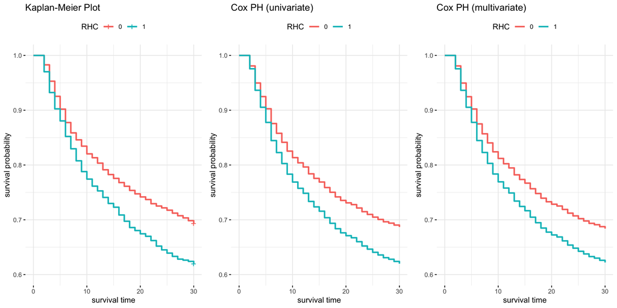

```r
# Univariate case
p_uni1 <- ggadjustedcurves(fit_uni1, data = rhc_psm_df,
      variable = "RHC",
      ylim = c(0.6, 1), legend = "top",
      legend.title = "RHC",
       ylab = 'survival probability',
       xlab = 'survival time',
       title = 'Cox PH (univariate)',
       ggtheme = theme_minimal())

# Multivariate case
p_all <- ggadjustedcurves(fit_all, data = rhc_psm_df,
      variable = "RHC",
      ylim = c(0.6, 1), legend = "top",
      legend.title = "RHC",
      ylab = 'survival probability',
      xlab = 'survival time',
      title = 'Cox PH (multivariate)',
      ggtheme = theme_minimal())

grid.arrange( p_km$plot, p_uni1, p_all, ncol = 3)
```

You might ask why did we put `p_km$plot` in `grid.arrange()` function? Similiar to the question before, `p_km` is a list created by function `ggsurvplot()` and it is not compatible with `grid.arrange()`. However, a function called `arrange_ggsurvplots()` can be used to arrange multiple `ggsurvplot` objects.

However, the other two plots are created by `ggadjustedcurves()`, which are compatible with `grid.arrange()`. There is an easy way to solve this issue: extract the `plot` object from list `p_km`.

The middle and right plots show survival curves for a matched dataset, corresponding to the univariate and multivariate models, respectively. In the multivariate case, the difference in the survival rate seems to be smaller than in the univariate case, but it is only a slight difference.

Compared with the Kaplan-Meier plot (left), whether we use a univariate or multivariate model, the difference of the survival rate between these two groups is attenuated. However, patients in the `RHC` group still have a lower survival rate than those in the `No RHC` group.

# Summary

In this case study, we explored the association between time to death and RHC based on an observational dataset collected over the course of 30 days. We covered various statistical topics to help us assess this association, such as survival analysis, propensity score matching and the Cox proportional hazards model. Based on our analyses, we can conclude that RHC has a positive relationship with the risk of mortality, even when adjusting for confounding variables.

We started by looking at the data, separating the dataset into two groups based on whether or not the subject received RHC, using the variable `RHC`. We made a table to show the distributions of all other variables in the two groups, and made some figures to visualize these differences. We found some variables have large differences, such as blood pressure and PaO2/FIO2 ratio, while others do not vary too much, like age.

Next we tried the Kaplan-Meier method, a non-parametric method, to explore the relationship between survival rate and whether a patient received RHC treatment or not. The result was shown as a survival curve plot. It provided us an initial understanding that the survival rate is higher in the population managed without RHC treatment.

But, since we are working with an observational dataset, the bias in treatment selection is an unavoidable problem, so these initial results may be misleading. To solve this problem, we made use of the causal inference method of propensity score matching. Logistic regression was applied to determine the probability of receiving RHC (propensity score), given an array of additional variables. This probability represented the relationship between multiple covariates and the use of RHC and was used as a criterion to match subjects. We matched subjects based on propensity score and finally kept 1862 pairs. As expected, the remaining data showed a much more balanced distribution of propensity scores across the two groups.

In the next step, we further improved our survival analysis model by using a parametric method, the Cox proportional hazards model. First we applied a univariate model, showing three examples. Then all necessary variables were included, to avoid ignoring potential confounders. We also evaluated the proportionality assumption that is made when using a Cox PH model, both with graphical checks and a statistical test. There is no obvious pattern with time so the assumption does not seem to be violated in our data set.

Our outcomes seem to directly oppoese the widespread belief that RHC is recommended in broad clinical applications. This may be caused by the fact that confounding variables which increase the probability of receiving RHC and the probability of death overall make it difficult to accurately assess the impact of RHC based on anecdotal observation. Our analysis, which attempts to control for these confounders, aims to produce a more rigorous statistical result, within the limitations of this observational data set. However, we admit the limitations of this study and are happy to receive additional suggestions to better understand the role of RHC.

# References

[1] Connors AF, Speroff T, Dawson NV, Thomas C, Harrell FE, Wagner D, et al. The effectiveness of right heart catheterization in the initial care of critically iii patients. Jama 1996;276:889–97.

[2] Klein JP, Moeschberger ML. Survival analysis: Techniques for censored and truncated data. Springer Science & Business Media; 2006.

[3] Austin PC. An introduction to propensity score methods for reducing the effects of confounding in observational studies. Multivariate Behavioral Research 2011;46:399–424.

[4] Grambsch PM, Therneau TM. Proportional hazards tests and diagnostics based on weighted residuals. Biometrika 1994;81:515–26.